# Project Part 2

Bailey Young, Sage Young, Matt Ramundo

Wednesday, May 06, 2020 @ 12:05 PM

### **Part A**

**Consider the model that you arrived at in the previous project as the first candidate model.**

```r
Housing <- read_excel("Housing.xlsx")
model_1 <- lm(data = Housing, price ~ size + bath + lot + elem  + status + log(bedrooms) + garagesize^2)
summary(model_1)
```

```
##
## Call:
## lm(formula = price ~ size + bath + lot + elem + status + log(bedrooms) +
##     garagesize^2, data = Housing)
##
## Residuals:
##     Min      1Q  Median      3Q     Max
## -90.265 -33.425  -0.399  24.978 102.317
##
## Coefficients:
##               Estimate Std. Error t value Pr(>|t|)
## (Intercept)    131.802     57.678   2.285  0.02568 *
## size            74.916     30.658   2.444  0.01736 *
## bath             6.343     11.262   0.563  0.57529
## lot             10.095      3.586   2.815  0.00650 **
## elemcrest        3.791     33.951   0.112  0.91145
## elemedge         6.936     28.956   0.240  0.81147
## elemedison      84.130     29.782   2.825  0.00633 **
## elemharris      53.380     30.381   1.757  0.08378 .
## elemparker     -11.404     29.883  -0.382  0.70401
## statuspen      -19.874     16.373  -1.214  0.22935
## statussld      -37.108     13.796  -2.690  0.00914 **
## log(bedrooms)  -51.748     31.116  -1.663  0.10127
## garagesize       8.606      8.742   0.984  0.32867
## ---
## Signif. codes:  0 '***' 0.001 '**' 0.01 '*' 0.05 '.' 0.1 ' ' 1
##
## Residual standard error: 44.52 on 63 degrees of freedom
## Multiple R-squared:  0.5426, Adjusted R-squared:  0.4555
## F-statistic: 6.229 on 12 and 63 DF,  p-value: 4.34e-07
```

### **Part B**

**Create a second candidate model by using regsubsets over the entire data set. You can decide whether you prefer overall selection, forward selection, or backward selection, and you can decide which statistic you will use to determine the best model from the regsubsets process. Just conduct a justifiable model selection process and report the predictors in your final model.**

```r
attach(Housing)

regfit.fwd <- regsubsets(price ~ ., data = Housing, nvmax = 9, method = "forward")
```

```
## Reordering variables and trying again:
```

```r
fwd.summary <- summary(regfit.fwd)
names(summary(regfit.fwd))
```

```
## [1] "which"  "rsq"    "rss"    "adjr2"  "cp"     "bic"    "outmat" "obj"
```

```r
fwd.summary$bic
```

```
##  [1]  -1.786348 -10.308111 -15.260032 -19.722081 -20.088837 -22.078434
##  [7] -20.062997 -17.675759 -15.064350 -11.641828
```

```r
fwd.summary$which
```

```
##    (Intercept)    id  size   lot  bath bedrooms yearbuilt agestandardized
## 1         TRUE FALSE FALSE FALSE FALSE    FALSE     FALSE           FALSE
## 2         TRUE FALSE FALSE FALSE FALSE    FALSE     FALSE           FALSE
## 3         TRUE FALSE FALSE FALSE FALSE    FALSE     FALSE           FALSE
## 4         TRUE FALSE FALSE  TRUE FALSE    FALSE     FALSE           FALSE
## 5         TRUE FALSE FALSE  TRUE FALSE    FALSE     FALSE           FALSE
## 6         TRUE FALSE  TRUE  TRUE FALSE    FALSE     FALSE           FALSE
## 7         TRUE FALSE  TRUE  TRUE FALSE     TRUE     FALSE           FALSE
## 8         TRUE FALSE  TRUE  TRUE FALSE     TRUE     FALSE           FALSE
## 9         TRUE FALSE  TRUE  TRUE FALSE     TRUE     FALSE           FALSE
## 10        TRUE  TRUE  TRUE  TRUE FALSE     TRUE     FALSE           FALSE
##    garagesize statuspen statussld elemcrest elemedge elemedison elemharris
## 1        TRUE     FALSE     FALSE     FALSE    FALSE      FALSE      FALSE
## 2        TRUE     FALSE     FALSE     FALSE    FALSE       TRUE      FALSE
## 3        TRUE     FALSE     FALSE     FALSE    FALSE       TRUE       TRUE
```

[output cut: 18 more lines]

The model with the lowest bic was our 6 predictor model, it consisted of the following predictors: size, lot, garagesize, statussld, elemedison, elemharris.

```r
regfit.bwd <- regsubsets(price ~ ., data = Housing, nvmax = 9, method = "backward")
```

```
## Reordering variables and trying again:
```

```r
bwd.summary <- summary(regfit.bwd)
bwd.summary$bic
```

```
##  [1]   1.572961  -3.936146 -13.398085 -18.379127 -22.483794 -22.610551
##  [7] -19.714693 -17.585937 -14.492413 -11.017226
```

```r
bwd.summary$which
```

```
##    (Intercept)    id  size   lot  bath bedrooms yearbuilt agestandardized
## 1         TRUE FALSE FALSE FALSE FALSE    FALSE     FALSE           FALSE
## 2         TRUE FALSE FALSE FALSE FALSE    FALSE     FALSE           FALSE
## 3         TRUE FALSE FALSE  TRUE FALSE    FALSE     FALSE           FALSE
## 4         TRUE FALSE FALSE  TRUE FALSE    FALSE     FALSE           FALSE
## 5         TRUE FALSE  TRUE  TRUE FALSE    FALSE     FALSE           FALSE
## 6         TRUE FALSE  TRUE  TRUE FALSE     TRUE     FALSE           FALSE
## 7         TRUE FALSE  TRUE  TRUE FALSE     TRUE     FALSE           FALSE
## 8         TRUE FALSE  TRUE  TRUE FALSE     TRUE     FALSE           FALSE
## 9         TRUE  TRUE  TRUE  TRUE FALSE     TRUE     FALSE           FALSE
## 10        TRUE  TRUE  TRUE  TRUE FALSE     TRUE     FALSE           FALSE
##    garagesize statuspen statussld elemcrest elemedge elemedison elemharris
## 1       FALSE     FALSE     FALSE     FALSE    FALSE       TRUE      FALSE
## 2       FALSE     FALSE     FALSE     FALSE    FALSE       TRUE       TRUE
## 3       FALSE     FALSE     FALSE     FALSE    FALSE       TRUE       TRUE
```

[output cut: 18 more lines]

Using backward selection, the model with the lowest bic is our 6 predictor model. It contains the follow predictors: size, lot, bedrooms, statussld, elemharris, and elemedison.

```r
regfit.all <- regsubsets(price ~ ., data= Housing, nvmax=9, really.big = TRUE)
```

```
## Reordering variables and trying again:
```

```r
all.summary <- summary(regfit.all)
all.summary$bic
```

```
##  [1]  -1.786348 -10.308111 -15.260032 -19.722081 -22.483794 -22.610551
##  [7] -20.390650 -17.675759 -15.064350 -11.641828
```

```r
all.summary$which
```

```
##    (Intercept)    id  size   lot  bath bedrooms yearbuilt agestandardized
## 1         TRUE FALSE FALSE FALSE FALSE    FALSE     FALSE           FALSE
## 2         TRUE FALSE FALSE FALSE FALSE    FALSE     FALSE           FALSE
## 3         TRUE FALSE FALSE FALSE FALSE    FALSE     FALSE           FALSE
## 4         TRUE FALSE FALSE  TRUE FALSE    FALSE     FALSE           FALSE
## 5         TRUE FALSE  TRUE  TRUE FALSE    FALSE     FALSE           FALSE
## 6         TRUE FALSE  TRUE  TRUE FALSE     TRUE     FALSE           FALSE
## 7         TRUE FALSE  TRUE  TRUE FALSE     TRUE     FALSE           FALSE
## 8         TRUE FALSE  TRUE  TRUE FALSE     TRUE     FALSE           FALSE
## 9         TRUE FALSE  TRUE  TRUE FALSE     TRUE     FALSE           FALSE
## 10        TRUE  TRUE  TRUE  TRUE FALSE     TRUE     FALSE           FALSE
##    garagesize statuspen statussld elemcrest elemedge elemedison elemharris
## 1        TRUE     FALSE     FALSE     FALSE    FALSE      FALSE      FALSE
## 2        TRUE     FALSE     FALSE     FALSE    FALSE       TRUE      FALSE
## 3        TRUE     FALSE     FALSE     FALSE    FALSE       TRUE       TRUE
```

[output cut: 18 more lines]

Using overall selection, our model with the lowest bic is once again our six predictor model. It contains the following predictors: size, lot, bedrooms, statussld, elemedison, and elemharris.

Looking over our results, we see that the best model using overall selection and backwards selection are the exact same. We also see that our best model found using forward selection is only different by one predictor.

```r
model_2 <- glm(price ~ size + lot + bedrooms + status + elem, data = Housing)
summary(model_2)
```

```
##
## Call:
## glm(formula = price ~ size + lot + bedrooms + status + elem,
##     data = Housing)
##
## Deviance Residuals:
##     Min       1Q   Median       3Q      Max
## -91.369  -29.241   -0.705   24.313  113.296
##
## Coefficients:
##             Estimate Std. Error t value Pr(>|t|)
## (Intercept)  118.460     54.739   2.164  0.03414 *
## size          90.210     26.319   3.428  0.00106 **
## lot           10.754      3.480   3.091  0.00294 **
## bedrooms     -15.786      8.018  -1.969  0.05324 .
## statuspen    -20.543     16.227  -1.266  0.21004
## statussld    -43.291     12.890  -3.359  0.00131 **
## elemcrest      1.261     33.763   0.037  0.97033
## elemedge      11.903     28.145   0.423  0.67376
## elemedison    85.616     29.470   2.905  0.00501 **
## elemharris    58.506     29.680   1.971  0.05296 .
## elemparker   -11.034     29.546  -0.373  0.71004
## ---
## Signif. codes:  0 '***' 0.001 '**' 0.01 '*' 0.05 '.' 0.1 ' ' 1
##
## (Dispersion parameter for gaussian family taken to be 1983.627)
##
##     Null deviance: 273002  on 75  degrees of freedom
## Residual deviance: 128936  on 65  degrees of freedom
## AIC: 804.84
##
## Number of Fisher Scoring iterations: 2
```

### **Part C**

**Create a training/test split of the data by which roughly half of the 76 observations are training data and half are test data.**

```r
set.seed(1)
trainingindex <- sample(1:nrow(Housing), nrow(Housing)*0.50)
train <- Housing[trainingindex, ]
test <- Housing[-trainingindex, ]
```

### **Part D**

**Now use regsubsets over only the training data to determine the number of predictors that should be in your final model. Then use regsubsets over the entire data set with the determined number of variables to determine your third candidate model.**

```r
regfit.best <- regsubsets(price ~ ., data = train, nvmax = 9, really.big = TRUE)
```

```
## Reordering variables and trying again:
```

```r
test.mat <- model.matrix(price ~ size + lot + bath + bedrooms + yearbuilt + agestandardized + garagesize + status + elem,data=test)

val.errors <- rep(NA,9)

for(i in 1:9){
  coefi=coef(regfit.best,id=i)
  pred=test.mat[,names(coefi)]%*%coefi
  val.errors[i] <- mean((test$price-pred)^2)
}

val.errors
```

```
## [1] 4549.240 4611.069 3790.141 3817.808 3923.469 3781.748 3529.826 3018.360
## [9] 2868.006
```

```r
which.min(val.errors)
```

```
## [1] 9
```

```r
coef(regfit.best,which.min(val.errors))
```

```
## (Intercept)        size         lot    bedrooms   statussld   elemcrest
##   48.170956   82.862798   15.156401   -6.140037  -32.420248   65.561184
##    elemedge  elemedison  elemharris  elemparker
##   36.823871  110.819543   92.735053    9.533553
```

```r
model_3 <- glm(price ~ size + lot + bedrooms + status + elem, data = Housing)
summary(model_3)
```

```
##
## Call:
## glm(formula = price ~ size + lot + bedrooms + status + elem,
##     data = Housing)
##
## Deviance Residuals:
##     Min       1Q   Median       3Q      Max
## -91.369  -29.241   -0.705   24.313  113.296
##
## Coefficients:
##             Estimate Std. Error t value Pr(>|t|)
## (Intercept)  118.460     54.739   2.164  0.03414 *
## size          90.210     26.319   3.428  0.00106 **
## lot           10.754      3.480   3.091  0.00294 **
## bedrooms     -15.786      8.018  -1.969  0.05324 .
## statuspen    -20.543     16.227  -1.266  0.21004
## statussld    -43.291     12.890  -3.359  0.00131 **
## elemcrest      1.261     33.763   0.037  0.97033
## elemedge      11.903     28.145   0.423  0.67376
## elemedison    85.616     29.470   2.905  0.00501 **
## elemharris    58.506     29.680   1.971  0.05296 .
## elemparker   -11.034     29.546  -0.373  0.71004
## ---
## Signif. codes:  0 '***' 0.001 '**' 0.01 '*' 0.05 '.' 0.1 ' ' 1
##
## (Dispersion parameter for gaussian family taken to be 1983.627)
##
##     Null deviance: 273002  on 75  degrees of freedom
## Residual deviance: 128936  on 65  degrees of freedom
## AIC: 804.84
##
## Number of Fisher Scoring iterations: 2
```

### **Part E**

**Next, use either Ridge Regression or Lasso Regression with the training data, and use cross validation via the cv.glmnet function to determine the best λ value. The model from this step with the best λ value will be your fourth candidate model.**

```r
train.matrix <- model.matrix(price ~ ., data = train)[,-1]
test.matrix <- model.matrix(price ~ ., data = test)[,-1]

grid = 10^seq(10,-2, length=100)

ridge.mod <- glmnet(train.matrix, train$price, alpha=0, lambda =grid)
ridge.fit <- cv.glmnet(train.matrix, train$price, alpha=0, lambda =grid)
```

```r
ridge.lambda <- ridge.fit$lambda.min
ridge.lambda
```

```
## [1] 18.73817
```

```r
ridge.pred <- predict(ridge.mod, s=ridge.lambda, newx=test.matrix)
```

```r
model_4 <- glmnet(train.matrix, train$price, alpha=0, lambda = 18.73817)
```

### **Part F**

**Finally, use either principal components regression or partial least squares regression for the training data. Use cross validation (see the class notes or the Chapter 6 Lab from the text) to help you determine the number of components in the model and briefly explain your choice. This model will be your 5th candidate model.**

```r
pls.fit <- plsr(price ~ ., data = train, scale = TRUE, validation = "CV")
summary(pls.fit)
```

[output not shown]

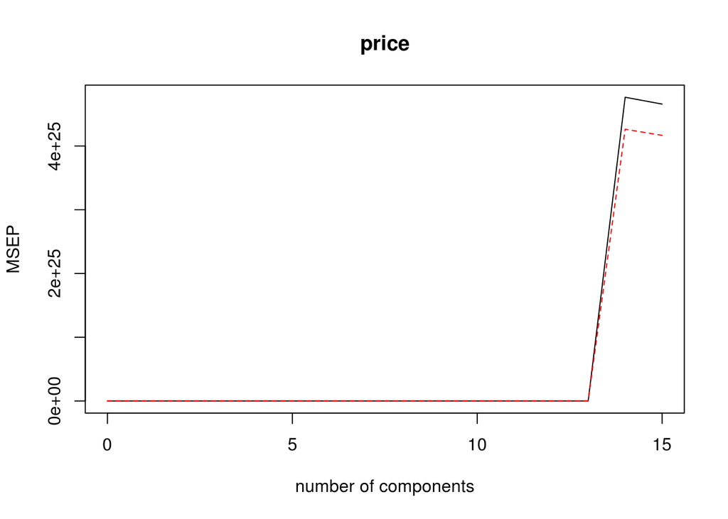

```r
validationplot(pls.fit, val.type = "MSEP")
```

```r
#M=2 components because at 2 components, the MSEP is the lowest.

pls.2m <- plsr(price~ ., data = Housing, scale = TRUE, ncomp=2)
summary(pls.2m)
```

```
## Data:    X dimension: 76 15
##  Y dimension: 76 1
## Fit method: kernelpls
## Number of components considered: 2
## TRAINING: % variance explained
##        1 comps  2 comps
## X        17.59    31.60
## price    37.79    50.85
```

### **Part G**

**For each of the five candidate models, calculate the mean square error for predicting the outcomes in the test data set that you created in Part C.**

```r
model_1 <- lm(data = train, price ~ size + bath + lot + elem  + status + log(bedrooms) + garagesize^2)
predict_1 <- predict(model_1, test)
mean((predict_1 - test$price)^2)
```

```
## [1] 2903.412
```

```r
#Note our results for parts B and D were the same therefore models 2 and 3 are the same model
model_3 <- glm(price ~ size + lot + bedrooms + status + elem, data = Housing)
predict_3 <- predict(model_3, test)
mean((predict_3 - test$price)^2)
```

```
## [1] 2197.164
```

```r
model_4 <- glmnet(train.matrix, train$price, alpha=0, lambda = 18.73817)

mean((ridge.pred - test$price)^2)
```

```
## [1] 2590.697
```

```r
model_5 <- plsr(price~ ., data = Housing, scale = TRUE, ncomp=2)
predict_5 <- predict(model_5, test)
mean((predict_5 - test$price)^2)
```

```
## [1] 2144.55
```

**Based on this comparison, which model do you prefer for this situation?**